# ps5

Xiangguang

2023-02-19

2. (2pt) Load data. How many rows/columns do we have?

```r
library(dplyr)
library(tidyverse)
data <- read_delim("gapminder.csv")
dim(data)
```

```
## [1] 13055    25
```

```
3. (2pt) Print a small sample of data. Does it look OK?
```

```r
rand_rows <- sample(nrow(data), 10)
data[rand_rows, ]
```

```
## # A tibble: 10 × 25
##    iso3  name       iso2  region sub-reg…¹ inter…²  time total…³ ferti…⁴ lifeE…⁵
##    <chr> <chr>      <chr> <chr>  <chr>     <chr>   <dbl>   <dbl>   <dbl>   <dbl>
##  1 ALB   Albania    AL    Europe Southern… <NA>     2007  2.97e6    1.67    75.6
##  2 MOZ   Mozambique MZ    Africa Sub-Saha… Easter…  2003  1.93e7    5.77    49.9
##  3 LBR   Liberia    LR    Africa Sub-Saha… Wester…  1978  1.74e6    6.95    44.9
##  4 EGY   Egypt      EG    Africa Northern… <NA>     1999  6.75e7    3.43    68.4
##  5 SRB   Serbia     RS    Europe Southern… <NA>     1983  7.47e6   NA       NA
##  6 GRC   Greece     GR    Europe Southern… <NA>     2006  1.10e7    1.4     79.4
##  7 MWI   Malawi     MW    Africa Sub-Saha… Easter…  1988  8.64e6    7.16    46.0
##  8 MRT   Mauritania MR    Africa Sub-Saha… Wester…  1998  2.50e6    5.50    60.6
##  9 AND   Andorra    AD    Europe Southern… <NA>     1965  1.85e4   NA       NA
## 10 JOR   Jordan     JO    Asia   Western … <NA>     1961  9.74e5    7.80    53.4
## # … with 15 more variables: childMortality <dbl>, youthFemaleLiteracy <dbl>,
## #   youthMaleLiteracy <dbl>, adultLiteracy <dbl>, GDP_PC <dbl>,
## #   accessElectricity <dbl>, agriculturalLand <dbl>, agricultureTractors <dbl>,
## #   cerealProduction <dbl>, fertilizerHa <dbl>, co2 <dbl>,
## #   greenhouseGases <dbl>, co2_PC <dbl>, pm2.5_35 <dbl>, battleDeaths <dbl>,
## #   and abbreviated variable names ¹`sub-region`, ²`intermediate-region`,
## #   ³totalPopulation, ⁴fertilityRate, ⁵lifeExpectancy
```

```
    2 Descriptive statistics (15pt)
```

1. (3pt) How many countries are there in the dataset? Analyze all three: iso3, iso2 and name.

```r
length(unique(data$iso2))
```

```
## [1] 249
```

```r
length(unique(data$name))
```

```
## [1] 250
```

```r
length(unique(data$iso3))
```

```
## [1] 253
```

2. If you did this correctly, you saw that there are more names than iso-2 codes, and there are even more iso3 -codes. What is going on? Can you find it out? (a) (5pt) Find how many names are there for each iso-2 code. Are there any iso-2 codes that correspond to more than one name? What are these countries?

```
(b) (5pt) Now repeat the same for name and iso3-code. Are there country names that have
```

more than one iso3-code? What are these countries?

```
Hint: two of these entitites are CHANISL and NLD CURACAO.
```

```r
countries <- unique(data[, c("name", "iso2", "iso3")])
countries
```

```
## # A tibble: 253 × 3
##    name                 iso2  iso3
##    <chr>                <chr> <chr>
##  1 Aruba                AW    ABW
##  2 Afghanistan          AF    AFG
##  3 Angola               AO    AGO
##  4 Anguilla             AI    AIA
##  5 Åland Islands        AX    ALA
##  6 Albania              AL    ALB
##  7 Andorra              AD    AND
##  8 United Arab Emirates AE    ARE
##  9 Argentina            AR    ARG
## 10 Armenia              AM    ARM
## # … with 243 more rows
```

There are some valid iso3 names does not have a name and iso2 for it.

```r
iso2names <- data %>%
  group_by(iso2) %>%
  summarise(num = n_distinct(name))
iso2names
```

```
## # A tibble: 249 × 2
##    iso2    num
##    <chr> <int>
##  1 AD        1
##  2 AE        1
##  3 AF        1
##  4 AG        1
##  5 AI        1
##  6 AL        1
##  7 AM        1
##  8 AO        1
##  9 AQ        1
## 10 AR        1
## # … with 239 more rows
```

```r
iso3names <- data %>%
  group_by(iso3) %>%
  summarise(num = n_distinct(name))
iso3names
```

```
## # A tibble: 253 × 2
##    iso3    num
##    <chr> <int>
##  1 ABW       1
##  2 AFG       1
##  3 AGO       1
##  4 AIA       1
##  5 ALA       1
##  6 ALB       1
##  7 AND       1
##  8 ARE       1
##  9 ARG       1
## 10 ARM       1
## # … with 243 more rows
```

There aren’t any iso3-code that have more than one name.

3. (2pt) What is the minimum and maximum year in these data?

```r
new_data <- data[complete.cases(data$time),]
max(new_data$time)
```

```
## [1] 2019
```

```r
min(new_data$time)
```

```
## [1] 1960
```

3 CO2 emissions (30pt) Next, let’s analyze CO2 emissions. 1. (2pt) How many missing co2 emissions are there for each year? Analyze both missing CO2 and co2_PC. Which years have most missing data?

```r
sum(is.na(data$co2))
```

```
## [1] 2658
```

```r
sum(is.na(data$co2_PC))
```

```
## [1] 2661
```

```r
missing <- data %>%
  group_by(time) %>%
  summarise(co2_missing = sum(is.na(data$co2)),
            co2_pc_missing = sum(is.na(data$co2_PC)))

missing_co2 <- missing[which.max(missing$co2_missing), "time"]
missing_co2_pc <- missing[which.max(missing$co2_pc_missing), "time"]

missing_co2
```

```
## # A tibble: 1 × 1
##    time
##   <dbl>
## 1  1960
```

```r
missing_co2_pc
```

```
## # A tibble: 1 × 1
##    time
##   <dbl>
## 1  1960
```

For both co2 and co2_pc, 1960 has the most missing data.

2. (5pt) Make a plot of total CO2 emissions over time for the U.S, China, and India. Add a few more countries of your choice. Explain what do you see.

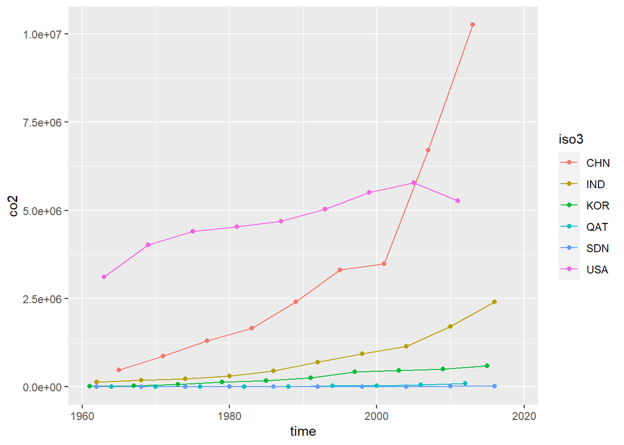

```r
data %>%
  filter(iso3 ==c( "USA", "CHN", "IND", "KOR", "SDN", "QAT")) %>%
  ggplot()+
  geom_line(aes(x=time, y = co2, col=iso3))+
  geom_point(aes(x=time, y = co2, col=iso3))
```

3. (5pt) Now let’s analyze the CO2 emissions per capita (co2_PC). Make a similar plot of the same countries. What does this figure suggest?

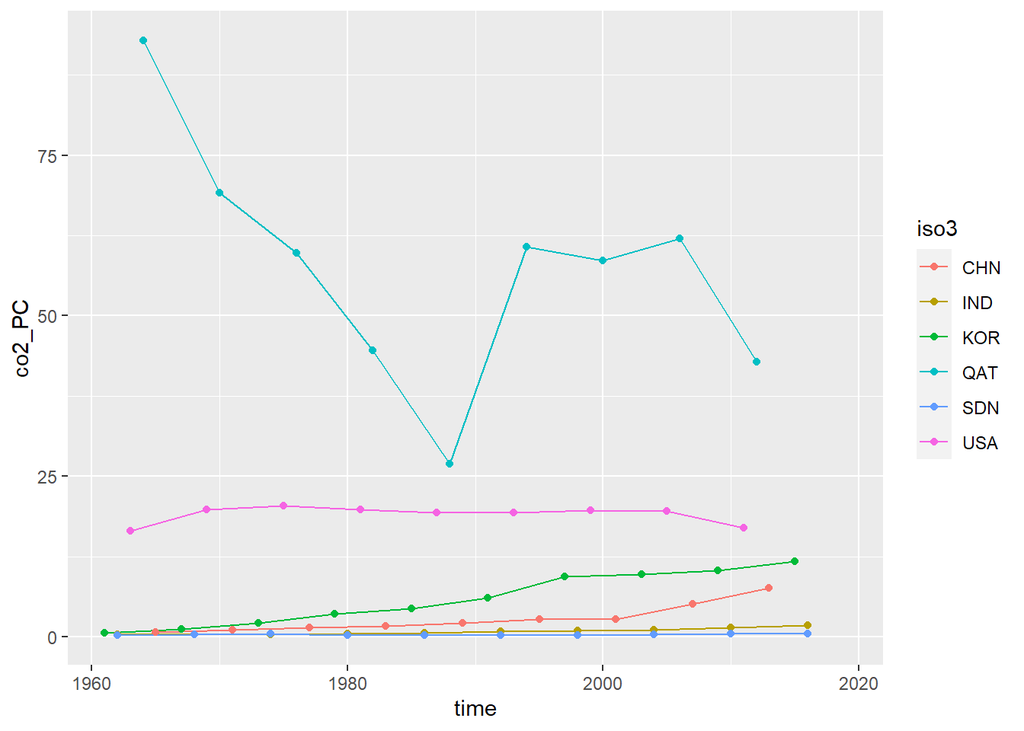

```r
data %>%
  filter(iso3 ==c( "USA", "CHN", "IND", "KOR", "SDN", "QAT")) %>%
  ggplot()+
  geom_line(aes(x=time, y = co2_PC, col=iso3))+
  geom_point(aes(x=time, y = co2_PC, col=iso3))
```

QAT has a very high co2 emission per captita comparing to other countries.

4. (6pt) Compute average CO2 emissions per capita across the continents (assume region is the same as continent). Comment what do you see. Note: just compute averages over countries and ignore the fact that countries are of different size.

```r
avg_co2_pc_continent_2016 <- data %>%
  filter(time == 2016) %>%
  group_by(region) %>%
  summarize(avg_co2_pc = mean(co2_PC, na.rm = TRUE))
avg_co2_pc_continent_2016$time <- 2016
avg_co2_pc_continent_2016 <- na.omit(avg_co2_pc_continent_2016)
avg_co2_pc_continent_2016
```

```
## # A tibble: 5 × 3
##   region   avg_co2_pc  time
##   <chr>         <dbl> <dbl>
## 1 Africa         1.20  2016
## 2 Americas       4.80  2016
## 3 Asia           6.47  2016
## 4 Europe         6.64  2016
## 5 Oceania        4.57  2016
```

```r
avg_co2_pc_continent_1960 <- data %>%
  filter(time == 1960) %>%
  group_by(region) %>%
  summarize(avg_co2_pc = mean(co2_PC, na.rm = TRUE))
avg_co2_pc_continent_1960$time <- 1960
avg_co2_pc_continent_1960 <- na.omit(avg_co2_pc_continent_1960)
avg_co2_pc_continent_1960
```

```
## # A tibble: 5 × 3
##   region   avg_co2_pc  time
##   <chr>         <dbl> <dbl>
## 1 Africa        0.291  1960
## 2 Americas      7.15   1960
## 3 Asia          1.74   1960
## 4 Europe        5.77   1960
## 5 Oceania       2.73   1960
```

In 2016, Europe has the highest average CO2_PC, and the second is Asia, the third is Americas. In 1960, Americas has the highest average CO2_PC, the second is Europe, and the third is Ocenia. Hint: Americas 2016 should be 4.80. 5. (7pt) Make a barplot where you show the previous results–average CO2 emissions per capita across continents in 1960 and 2016.

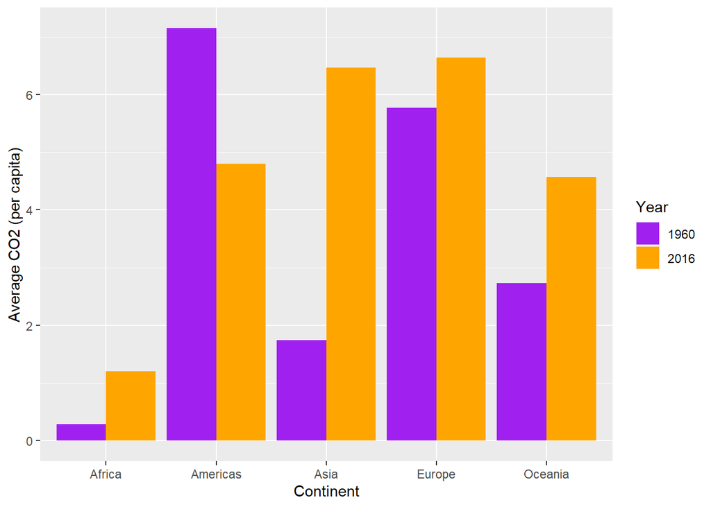

```r
avg_co2_pc_both <- rbind(avg_co2_pc_continent_1960, avg_co2_pc_continent_2016)
ggplot(avg_co2_pc_both, aes(x = region, y = avg_co2_pc, fill = factor(time))) +
  geom_bar(stat = "identity", position = "dodge") +
  scale_fill_manual(values = c("purple", "orange")) +
  labs(x = "Continent", y = "Average CO2 (per capita)", fill = "Year")
```

6. Which countries are the three largest, and three smallest CO2 emitters (in terms of CO2 per capita) in 2019 for each continent? (Assume region is continent).

```r
valid_data <- data %>% filter(!is.na(co2_PC))
vliad_data_2016 <- valid_data %>% filter(time == 2016) %>%
  group_by(region) %>%
  slice_max(order_by = co2_PC, n = 3) %>%
  bind_rows(valid_data %>% filter(time == 2016) %>%
              group_by(region) %>%
              slice_min(order_by = co2_PC, n = 3))
vliad_data_2016
```

```
## # A tibble: 34 × 25
## # Groups:   region [6]
##    iso3  name         iso2  region sub-r…¹ inter…²  time total…³ ferti…⁴ lifeE…⁵
##    <chr> <chr>        <chr> <chr>  <chr>   <chr>   <dbl>   <dbl>   <dbl>   <dbl>
##  1 ZAF   South Africa ZA    Africa Sub-Sa… Southe…  2016  5.62e7    2.46    63.2
##  2 LBY   Libya        LY    Africa Northe… <NA>     2016  6.49e6    2.32    72.3
##  3 SYC   Seychelles   SC    Africa Sub-Sa… Easter…  2016  9.47e4    2.39    74.3
##  4 TTO   Trinidad an… TT    Ameri… Latin … Caribb…  2016  1.38e6    1.75    73.1
##  5 USA   United Stat… US    Ameri… Northe… <NA>     2016  3.23e8    1.82    78.5
##  6 CAN   Canada       CA    Ameri… Northe… <NA>     2016  3.61e7    1.54    81.9
##  7 QAT   Qatar        QA    Asia   Wester… <NA>     2016  2.65e6    1.91    79.9
##  8 KWT   Kuwait       KW    Asia   Wester… <NA>     2016  3.96e6    2.08    75.2
##  9 BHR   Bahrain      BH    Asia   Wester… <NA>     2016  1.43e6    2.03    76.9
## 10 GIB   Gibraltar    GI    Europe Southe… <NA>     2016  3.37e4   NA       NA
## # … with 24 more rows, 15 more variables: childMortality <dbl>,
## #   youthFemaleLiteracy <dbl>, youthMaleLiteracy <dbl>, adultLiteracy <dbl>,
## #   GDP_PC <dbl>, accessElectricity <dbl>, agriculturalLand <dbl>,
## #   agricultureTractors <dbl>, cerealProduction <dbl>, fertilizerHa <dbl>,
## #   co2 <dbl>, greenhouseGases <dbl>, co2_PC <dbl>, pm2.5_35 <dbl>,
## #   battleDeaths <dbl>, and abbreviated variable names ¹`sub-region`,
## #   ²`intermediate-region`, ³totalPopulation, ⁴fertilityRate, ⁵lifeExpectancy
```

The largest 3: Africa：South Africa, Libya, Seychelles Americas: Trinidad and Tobago, USA, Canada Asia: Qatar, Kuwait, Bahrain Europe: Gibraltar, Luxembourg, Faroe Islands Oceania: New Caledonia, Australia, Palau

The smallest 3: Africa: Congo, Somalia, Burundi Americas: Haiti, Nicaragua, Honduras Asia: Afghanistan, Nepal, Yemen Europe: Liechtenstein, Albania, Republic of Moldova. Oceania: Solomon Islands, Vanuatu, Kiribati

4 GDP per capita (50pt) Let’s look at GDP per capita (GDP_PC). 1. (8pt) Make a scatterplot of GDP per capita versus life expectancy by country, using data for 1960. Make the point size dependent on the country size, and color those according to the continent. Feel free to adjust the plot in other ways to make it better. Comment what do you see there.

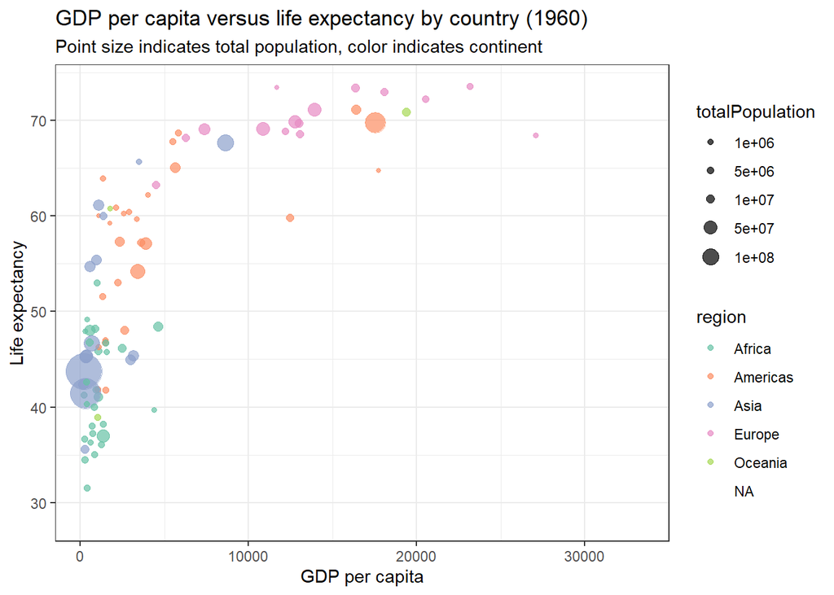

```r
data_1960 <- data %>% filter(time == 1960)
ggplot(data_1960, aes(x = GDP_PC, y = lifeExpectancy, size = totalPopulation, color = region)) +
  geom_point(alpha=0.7) +
  scale_color_brewer(type = "qual", palette = "Set2") +
  scale_size_continuous(range = c(1, 10), breaks = c(1000000, 5000000, 10000000, 50000000, 100000000)) +
  xlab("GDP per capita") +
  ylab("Life expectancy") +
  labs(title = "GDP per capita versus life expectancy by country (1960)",
       subtitle = "Point size indicates total population, color indicates continent") +
  theme_bw()
```

2. (4pt) Make a similar plot, but this time use 2019 data only. 3

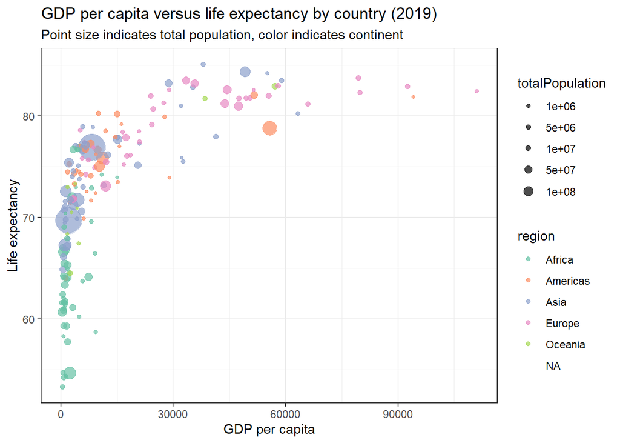

```r
data_2019 <- data %>% filter(time == 2019)
ggplot(data_2019, aes(x = GDP_PC, y = lifeExpectancy, size = totalPopulation, color = region)) +
  geom_point(alpha=0.7) +
  scale_color_brewer(type = "qual", palette = "Set2") +
  scale_size_continuous(range = c(1, 10), breaks = c(1000000, 5000000, 10000000, 50000000, 100000000)) +
  xlab("GDP per capita") +
  ylab("Life expectancy") +
  labs(title = "GDP per capita versus life expectancy by country (2019)",
       subtitle = "Point size indicates total population, color indicates continent") +
  theme_bw()
```

3. (6pt) Compare these two plots and comment what do you see. How has world developed through the last 60 years? As we can see from the plots, the life expectancy and GDP per capita has improved across the entire world. However, Africa falls behind compared to other continent.
4. (6pt) Compute the average life expectancy for each continent in 1960 and 2019. Do the results fit with what do you see on the figures?

Note: here as average I mean just average over countries, ignore the fact that countries are of different size.

```r
avg_life_expectancy_1960 <- data %>%
  filter(time == 1960) %>%
  group_by(region) %>%
  summarize(avg_life_expectancy = mean(lifeExpectancy, na.rm = TRUE))
avg_life_expectancy_1960
```

```
## # A tibble: 6 × 2
##   region   avg_life_expectancy
##   <chr>                  <dbl>
## 1 Africa                  41.5
## 2 Americas                58.6
## 3 Asia                    51.6
## 4 Europe                  68.3
## 5 Oceania                 56.4
## 6 <NA>                    70.7
```

```r
# Compute average life expectancy by continent in 2019
avg_life_expectancy_2019 <- data %>%
  filter(time == 2019) %>%
  group_by(region) %>%
  summarize(avg_life_expectancy = mean(lifeExpectancy, na.rm = TRUE))
avg_life_expectancy_2019
```

```
## # A tibble: 6 × 2
##   region   avg_life_expectancy
##   <chr>                  <dbl>
## 1 Africa                  64.1
## 2 Americas                75.8
## 3 Asia                    74.6
## 4 Europe                  79.4
## 5 Oceania                 73.5
## 6 <NA>                    77.8
```

Yes it does

5. (8pt) Compute the average LE growth from 1960-2019 across the continents. Show the results in the order of growth. Explain what do you see. Hint: these data (data in long form) is not the simplest to compute growth. But you may want to check out the lag() function. And do not forget to group data by continent when using lag(), otherwise your results will be messed up! See https://faculty.washington. edu/otoomet/info201-book/dplyr.html#dplyr-helpers-compute.

```r
data_growth <- data %>%
  group_by(region) %>%
  mutate(data_growth = (lifeExpectancy -
  lag(lifeExpectancy))/lag(lifeExpectancy)) %>%
  filter(time > 1960 & time < 2019) %>%
  summarize(avg_growth = mean(data_growth, na.rm=TRUE)) %>%
  arrange(desc(avg_growth))
data_growth <- na.omit(data_growth)
data_growth
```

```
## # A tibble: 5 × 2
##   region   avg_growth
##   <chr>         <dbl>
## 1 Africa      0.00749
## 2 Asia        0.00656
## 3 Oceania     0.00467
## 4 Americas    0.00441
## 5 Europe      0.00258
```

6. (6pt) Show the histogram of GDP per capita for years of 1960 and 2019. Try to put both histograms on the same graph, see how well you can do it!

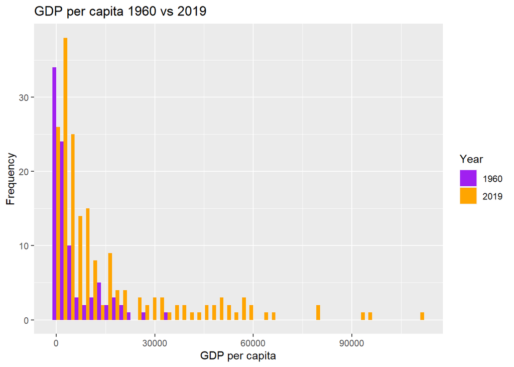

```r
GDP_both <- data %>%
  filter(time %in% c(1960, 2019))

ggplot(GDP_both, aes(x = GDP_PC, fill = factor(time))) +
  geom_histogram(position = "dodge", bins = 50) +
  scale_fill_manual(values = c("purple", "orange"), name = "Year") +
  labs(title = "GDP per capita 1960 vs 2019", x =
         "GDP per capita", y = "Frequency")
```

7. (6pt) What was the ranking of US in terms of life expectancy in 1960 and in 2019? (When counting from top.) Hint: check out the function rank()! Hint2: 17 for 1960.

```r
data_with_name <- subset(data,!is.na(name))
rank_1960 <- data_with_name %>%
  filter(time == 1960) %>%
  arrange(desc(lifeExpectancy)) %>%
  mutate(rank = rank(-lifeExpectancy, na.last = TRUE)) %>%
  filter(name == "United States of America")
rank_1960
```

```
## # A tibble: 1 × 26
##   iso3  name  iso2  region sub-r…¹ inter…²  time total…³ ferti…⁴ lifeE…⁵ child…⁶
##   <chr> <chr> <chr> <chr>  <chr>   <chr>   <dbl>   <dbl>   <dbl>   <dbl>   <dbl>
## 1 USA   Unit… US    Ameri… Northe… <NA>     1960  1.81e8    3.65    69.8    30.1
## # … with 15 more variables: youthFemaleLiteracy <dbl>, youthMaleLiteracy <dbl>,
## #   adultLiteracy <dbl>, GDP_PC <dbl>, accessElectricity <dbl>,
## #   agriculturalLand <dbl>, agricultureTractors <dbl>, cerealProduction <dbl>,
## #   fertilizerHa <dbl>, co2 <dbl>, greenhouseGases <dbl>, co2_PC <dbl>,
## #   pm2.5_35 <dbl>, battleDeaths <dbl>, rank <dbl>, and abbreviated variable
## #   names ¹`sub-region`, ²`intermediate-region`, ³totalPopulation,
## #   ⁴fertilityRate, ⁵lifeExpectancy, ⁶childMortality
```

```r
rank_2019 <- data_with_name %>%
  filter(time == 2019) %>%
  arrange(desc(lifeExpectancy)) %>%
  mutate(rank = rank(-lifeExpectancy, na.last = "keep")) %>%
  filter(name == "United States of America")
rank_2019
```

```
## # A tibble: 1 × 26
##   iso3  name  iso2  region sub-r…¹ inter…²  time total…³ ferti…⁴ lifeE…⁵ child…⁶
##   <chr> <chr> <chr> <chr>  <chr>   <chr>   <dbl>   <dbl>   <dbl>   <dbl>   <dbl>
## 1 USA   Unit… US    Ameri… Northe… <NA>     2019  3.28e8    1.70    78.8     6.5
## # … with 15 more variables: youthFemaleLiteracy <dbl>, youthMaleLiteracy <dbl>,
## #   adultLiteracy <dbl>, GDP_PC <dbl>, accessElectricity <dbl>,
## #   agriculturalLand <dbl>, agricultureTractors <dbl>, cerealProduction <dbl>,
## #   fertilizerHa <dbl>, co2 <dbl>, greenhouseGases <dbl>, co2_PC <dbl>,
## #   pm2.5_35 <dbl>, battleDeaths <dbl>, rank <dbl>, and abbreviated variable
## #   names ¹`sub-region`, ²`intermediate-region`, ³totalPopulation,
## #   ⁴fertilityRate, ⁵lifeExpectancy, ⁶childMortality
```

The US rank in 1960 is 17. The US rank in 2019 is 46.

8. (6pt) If you did this correctly, then you noticed that US ranking has been falling quite a bit. But we also have more countries in 2019–what about the relative rank divided by the corresponding number of countries that have LE data in the corresponding year? Hint: 0.0904 for 1960

```r
n_countries_1960 <- data_with_name %>%
  filter(time == 1960 & !is.na(lifeExpectancy)) %>%
  nrow()
rank_1960$rank/n_countries_1960
```

```
## [1] 0.09042553
```

```r
n_countries_2019 <- data_with_name %>%
  filter(time == 2019 & !is.na(lifeExpectancy)) %>%
  nrow()
rank_2019$rank/n_countries_2019
```

```
## [1] 0.2346939
```

I spent 6 hours on this HW